```python
from IPython.display import Image
from IPython.core.display import HTML
display(Image(url= "https://upload.wikimedia.org/wikipedia/fr/thumb/6/62/Logovend%C3%A9eG.svg/1200px-Logovend%C3%A9eG.svg.png", width=950, unconfined=True))
```

# PROJET KIT START DATA SCIENCE - INFMDI721

### TA Quang-Vinh Julien - Mastère Spécialisé Big Data

#### Import des packages utilisés dans ce notebook

```python
import datetime
import os
import re

import random
import wikipedia
import numpy as np
import pandas as pd
import xlwings
import requests
import matplotlib.pyplot as plt
import seaborn as sns
import multiprocessing as mp
import warnings

from datetime import datetime
from bs4 import BeautifulSoup
from matplotlib import cm
from sklearn.cluster import KMeans
from yellowbrick.cluster import KElbowVisualizer
from ipyleaflet import Map, AntPath, basemaps, Marker, basemap_to_tiles, LayersControl, ZoomControl, LayerGroup, \
    Polyline, FullScreenControl, WidgetControl, AwesomeIcon
from ipywidgets import HTML, IntSlider, jslink, Layout

warnings.filterwarnings('ignore')

# conda install -c conda-forge yellowbrick to install yellowbrick-1.3.post1 because yellowbrick-1.2 is deprecated
```

#### Setup des paramètres généraux

```python
desired_width = 320
pd.set_option('display.width', desired_width)
pd.set_option('display.max_columns', 13)
np.set_printoptions(linewidth=desired_width)
root_site = 'https://www.vendeeglobe.org'
```

## RECUPERATION DES DONNEES SUR LE SITE DU VENDEE GLOBE

#### Fonctions permettant la récupération et le scraping des données du site du vendeeglobe

Nous remarquons que sur le site sur le site du classement de la course du vendeeglobe, nous avons un menu déroulant permettant de sélectionner toutes les différentes dates et les classements publiés. Nous allons donc nous servir de ce menu déroulant pour récupérer les différents fichiers excels des classements et nous permettre d'effectuer les analyses

```python
display(Image(url="https://i.imgur.com/0IVa0nh.png", width=250))
```

[figure not shown]

```python
def get_parsed_page(url):
    headers = {
        "referer": f"{root_site}/fr/classement",
        "user-agent": "Mozilla/5.0 (X11; Ubuntu; Linux x86_64; rv:65.0)"
    }
    return BeautifulSoup(requests.get(url, headers=headers).text, "html.parser")

def get_full_list():
    page = get_parsed_page(f'{root_site}/fr/classement')
    return [elt['value'] for elt in page.find_all('option') if elt['value'] != '']
```

```python
# Récupération du nombre de dates inscrites sur le menu déroulant
fichiers = get_full_list()
len(fichiers)
```

```
706
```

La fonction suivante va nous permettre de télécharger automatiquement tous les fichiers .xlsx présents sur le site. Elle repose sur l'utilisation de *requests.get* pour permettre la récupération des fichiers. Une vérification du dossier \excel\ est effectué au préalable afin de vérifier si le fichier existe déjà ou non. Si le fichier existe, il ne le re-télécharge pas. Nous remarquons que le format des fichiers Excel change avec l'arrivée des voiliers à partir du 27 janvier 2021 à 17h00. Nous allons donc placer tous les fichiers Excel avant cette date dans le dossier \excels\ pour l'analyse, puis les fichiers suivant dans le dossier \finisher\ afin de ne pas mélanger les deux formats de fichiers.

```python
date_first_finisher = "20210127_170000"
date_time_first_finisher = datetime.strptime(date_first_finisher, "%Y%m%d_%H%M%S")
```

```python
def download_file(filenames):
    for filename in filenames:
        datetime_file = datetime.strptime(filename, "%Y%m%d_%H%M%S")
        if datetime_file < date_time_first_finisher:
            downloadPath = f"{os.getcwd()}\\excels\\"
        else:
            downloadPath = f"{os.getcwd()}\\finisher\\"
        # print(f'Downloading... {filename}')
        theList = os.listdir(downloadPath)
        name = f"{downloadPath}{filename}.xlsx"
        if name not in theList:
            url = f'{root_site}/download-race-data/vendeeglobe_{filename}.xlsx'
            response = requests.get(url)
            xlsx = open(name, 'wb')
            xlsx.write(response.content)
            xlsx.close()
        theList_new = os.listdir(downloadPath)
        s = set(theList)
        theList_diff = [x for x in theList_new if x not in s]
        if theList_diff:
            print(f'Add to Folder : {theList_diff[0]}')
            # filePath = os.path.join(downloadPath, filename)
            # print(f"Downloaded file: {theList_diff[0]} in {filePath}")
            xlsx_broken(name)
        else:
            print(f'No datas added - {filename} Already existing')
    print("All files downloaded")
```

```python
# Les fichiers étant déjà téléchargés une première fois, l'appel de la fonction est mise en commentaire a
# fin d'éviter de re-télécharger les fichiers à chaque "run all"

# download_file(fichiers)
```

```python
# On compte le nombre de fichier total récupéré
downloadPath_excel = f"{os.getcwd()}\\excels\\"
count_files = len(os.listdir(downloadPath_excel))
downloadPath_finisher = f"{os.getcwd()}\\finisher\\"
count_files2 = len(os.listdir(downloadPath_finisher))

print(f'Dossier Excel : {count_files}, Dossier Finisher : {count_files2}, Total : {count_files+count_files2}')
```

```
Dossier Excel : 483, Dossier Finisher : 220, Total : 703
```

Nous remarquons qu'il n'y a que 703 fichiers au lieu des 706 de la liste déroulante. Nous allons effectuer la comparaison afin de voir d'où vient la différence.

```python
diff = fichiers.copy()
compare  = os.listdir(downloadPath_excel)+os.listdir(downloadPath_finisher)
for elt in compare:
    if elt[:-5] in diff:
        diff.remove(elt[:-5])

print(diff)
```

```
['20210109_040000', '20201230_110000', '20201213_210000']
```

**Explication :** La différence sur ces 3 dates et heure c'est qu'elles sont présentes en doublon dans le menu déroulant. Il est donc normal de n'avoir que 703 fichiers au lieu de 706 (cf exemple image ci dessous).

```python
display(Image(url="https://i.imgur.com/gzJzEil.png", width=250))
```

[figure not shown]

**Nota bene:** Tous les fichiers téléchargés présentaient un problème au niveau de l'ouverture avec Pandas (utilisation de pd.read_excel(). Ces fichiers ont probablement été générés automatiquement par un logiciel et non spécifiquement via Excel ce qui provoquait une erreur de type  
*"TypeError: __init__() got an unexpected keyword argument 'xxid'".*  
Il s'avère que lorsque j'ouvrais le fichier Excel et que je ne faisais que le sauvegarder, celui-ci redevenait lisible par Pandas. Afin de palier à ce problème, j'ai donc utilisé la librairie xlwings et la fonction suivante pour pouvoir ouvrir tous les fichiers, puis les sauvegarder et enfin les refermer afin de tous les rendre lisible par Pandas.  
Des investigations plus poussées ont montré qu'il s'agissait un problème présent sur les nouvelles version de pyopenxl le moteur qu'utilise Pandas pour ouvrir les fichiers .xlsx.

```python
def xlsx_broken(file):
    excel_app = xlwings.App(visible=False)
    excel_book = excel_app.books.open(file)
    excel_book.save()
    excel_book.close()
    excel_app.quit()
    return
```

```python
# Nous aurions pu également utiliser le moyen défini sur le github :
""""
from urllib import request
import shutil

url = 'URL du fichier Excel à télécharger'
filename = 'exemple.xlsx'

with request.urlopen(url) as response, open(filename, 'wb') as out_file: shutil.copyfileobj(response, out_file)
"""
# Mais ayant déjà traité les fichiers avant la publication de cette solution, nous allons garder la méthode initiale.
```

```
'"\nfrom urllib import request\nimport shutil\n\nurl = \'URL du fichier Excel à télécharger\'\nfilename = \'exemple.xlsx\'\n\nwith request.urlopen(url) as response, open(filename, \'wb\') as out_file: shutil.copyfileobj(response, out_file)\n'
```

## ANALYSE DES DONNEES DES FICHIERS EXCELS

#### Mise en place des fonctions permettant le traitement des fichiers

Cette première fonction est similaire à celle utilisée lors de la session 2 du module Kit Data Science. Elle va nous permettre de convertir les coordonnées GPS en décimale afin de pouvoir plus facilement les utiliser

```python
def dms2dec(coord, ranking):
    list_coord = []
    for val,rank in zip(coord, ranking):
        if (rank == 'RET') or (rank == 'NL'):
            list_coord.append('NaN')
        else:
            deg, minutes, axis =  re.split('[°\']', val)
            list_coord.append((float(deg) + float(minutes)/60) * (-1 if axis in ['W', 'S'] else 1))
    return list_coord
```

Ces trois fonctions sont utilisées dans les "apply" des Series des Dataframe afin de pouvoir faciliter le nettoyage des données

```python
def pattern_time(x):
    if '-' in x:
        return x[:x.find("-")]
    elif '+' in x:
        return x[:x.find("+")]
    else:
        return x


def correction_voile(x):
    if x == "77" or x == "777":
        return "0777"
    elif x == "16":
        return "0010"
    else:
        return "%04d" % int(x)

def reformat_numericals(x):
    return x.replace('m', '').replace(',', '.').replace(' ', '').replace('tonnes', '').replace('t', '')
```

Mise en place d'une fonction permettant d'afficher correctement le classement final et de mettre en forme les colonnes pour pouvoir faire une analyse dessus.

```python
def render_final_ranking(file):
    columns_to_keep = [1, 2, 3, 7, 8, 13, 15, 16, 17, 18, 19, 20]
    column_name = ['Ranking', 'Nationality', 'Skipper', 'Date_arrival', 'Time', 'Gap_first', 'Gap_previous', 'Speed_OO',
                   'Distance_OO', 'Percent', 'Speed_OG', 'Distance_OG']
    df = pd.read_excel(file, usecols=columns_to_keep, names=column_name)
    classement_date = df.iloc[1, 0]
    df["Nat"] = df['Nationality'].str.extract('([a-zA-Z]{3})')
    df['Number'] = df['Nationality'].str.extract('(\d+)')
    df['Number'] = df['Number'].apply(lambda x: correction_voile(x) if x is not np.nan else x)
    df.drop(['Nationality'], axis=1, inplace=True)
    df.drop(range(4), axis=0, inplace=True)
    df.drop(df.tail(4).index, inplace=True)
    df = df.reset_index(drop=True)
    df = df.replace(r'\n', ' ', regex=True)
    df['Time'] = df['Time'].apply(lambda x: pattern_time(str(x)))
    df[['Ranking', 'Arrived']] = df.Ranking.str.split(" ", expand=True, )
    df.Arrived.fillna(value=np.nan, inplace=True)
    df.Time.fillna(value=np.nan, inplace=True)

    for cut in ['Speed_OO', 'Distance_OO', 'Percent', 'Speed_OG', 'Distance_OG']:
        df[cut] = df[cut].apply(lambda x: float(str(x).split(' ')[0]))

    return classement_date, df
```

```python
# Nous affichons la dataframe du dernier classement avec la liste des 5 premiers skippers
df = (render_final_ranking(f"{os.getcwd()}\\finisher\\20210305_080000.xlsx")[1])
df.head()
```

|  | Ranking | Skipper | Date_arrival | Time | Gap_first | Gap_previous | ... | Percent | Speed_OG | Distance_OG | Nat | Number | Arrived |
| --- | --- | --- | --- | --- | --- | --- | --- | --- | --- | --- | --- | --- | --- |
| 0 | 1 | Yannick Bestaven Maître Coq IV | 28/01/2021 04:19:46 FR | 80j 03h 44min 46s | NaN | NaN | ... | 117.3 | 14.8 | 28583.8 | FRA | 0017 | ARV |
| 1 | 2 | Charlie Dalin APIVIA | 27/01/2021 20:35:47 FR | 80j 06h 15min 47s | 02h 31min 01s | 02h 31min 01s | ... | 119.6 | 15.1 | 29135.0 | FRA | 0079 | ARV |
| 2 | 3 | Louis Burton Bureau Vallée 2 | 28/01/2021 00:45:12 FR | 80j 10h 25min 12s | 06h 40min 26s | 04h 09min 25s | ... | 117.6 | 14.8 | 28650.0 | FRA | 0018 | ARV |
| 3 | 4 | Jean Le Cam Yes we Cam ! | 28/01/2021 20:19:55 FR | 80j 13h 44min 55s | 10h 00min 09s | 03h 19min 43s | ... | 112.9 | 14.1 | 27501.5 | FRA | 0001 | ARV |
| 4 | 5 | Boris Herrmann Seaexplorer - Yacht Club De Monaco | 28/01/2021 11:19:45 FR | 80j 14h 59min 45s | 11h 14min 59s | 01h 14min 50s | ... | 116.8 | 14.7 | 28448.5 | MON | 0010 | ARV |

5 rows × 14 columns

**Conclusion :** Nous pouvons voir que le vainqueur de l'édition 2020 du Vendée Globe est **Yannick Bestave**.  
Ceci ne se reflète pas sur le premier arrivé qui est Charlie Dalin car il y a eu des compensations au niveau du temps final pour le sauvetage de **Kevin Escoffier** ce qui lui a permis d'avoir la première place après recalcul des temps à l'arrivée.

#### Récupération des informations sur les voiliers utilisés

Nous allons à nouveau scrapper le site pour trouver les différents skippers ainsi que les attributs des bateaux.

```python
def get_skippers_url_name(root_site):
    soup = get_parsed_page(root_site)
    url_skippers = []
    skipper_name = []
    for url in soup.find_all('a', class_='skippers__slide'):
        url_skippers.append(root_site + url.attrs['href'])
    for tag2 in soup.find_all('div', class_='menu-skippers__item__right'):
        skipper_name.append([tag2.get_text().split(' ')[28], tag2.get_text().split(' ')[29]])
    return url_skippers, skipper_name
```

```python
print(get_skippers_url_name(root_site)[0][1], get_skippers_url_name(root_site)[1][1])
```

```
https://www.vendeeglobe.org/fr/skippers/110/romain-attanasio ['Romain', 'ATTANASIO']
```

```python
wiki = wikipedia.page(f"{get_skippers_url_name(root_site)[1][0][0]} {get_skippers_url_name(root_site)[1][0][1]}")
print(wiki.title)
print(wiki.url)
```

```
Fabrice Amedeo
https://en.wikipedia.org/wiki/Fabrice_Amedeo
```

**Note:** Une fonctionnalité qui serait à approfondir serait de pouvoir afficher les page wikipédia associées à tous les skippers, mais les noms et prénoms n'étant parfois pas exactement les même cela ne match pas. Il faudrait faire une correspondance approximative la plus rapprochée.  
Néanmoins la fonctionnalité wikipedia.search peut nous donner une suggestion de résultats

Récupération des données des voiliers et mise en forme / nettoyage des colonnes

```python
def get_boat_spec(site):
    soup = get_parsed_page(site)
    boat = {}
    num = ''
    i = 0
    skipper_and_boat_name = soup.find_all('div', class_="boats-list__infos")
    for spec in soup.find_all('ul', class_="boats-list__popup-specs-list"):
        boatname = skipper_and_boat_name[i].find('h3', class_="boats-list__boat-name").get_text()
        skippername = skipper_and_boat_name[i].find('span', class_="boats-list__skipper-name").get_text()
        if skippername == 'Thomas RUYANT':
            num = "FRA 59"
            boat[num] = {}
        for attrib in spec.find_all('li'):
            a = (attrib.get_text())
            before = a[:a.find(':')][:-1]
            if before == 'Numéro de voile':
                num = a[a.find(':') + 2:]
                boat[num] = {}
            else:
                boat[num][a[:a.find(':')]] = a[a.find(':') + 2:]
            boat[num]['name'] = boatname
            boat[num]['skipper'] = skippername
        i += 1
    boat_df = pd.DataFrame.from_dict(boat, orient='index')
    boat_df['Tirant d\'eau '] = boat_df['Tirant d\'eau '].apply(lambda x: reformat_numericals(x))
    boat_df['Largeur '] = boat_df['Largeur '].apply(lambda x: reformat_numericals(x))
    boat_df['Longueur '] = boat_df['Longueur '].apply(lambda x: reformat_numericals(x))
    boat_df['Hauteur mât '] = boat_df['Hauteur mât '].apply(lambda x: reformat_numericals(x))
    boat_df['Déplacement (poids) '] = boat_df['Déplacement (poids) '].apply(lambda x: reformat_numericals(x))
    boat_df['Surface de voiles au portant '] = boat_df['Surface de voiles au portant '].str.extract('(\d+)')
    boat_df['Surface de voiles au près '] = boat_df['Surface de voiles au près '].str.extract('(\d+)')
    boat_df['Number'] = boat_df.index.values
    boat_df['Number'] = boat_df['Number'].str.extract('(\d+)')
    boat_df['Number'] = boat_df['Number'].apply(lambda x: correction_voile(x) if x is not np.nan else x)
    boat_df.rename(
        columns={"Surface de voiles au portant ": "Surf_vportant", "Surface de voiles au près ": "Surf_vpres",
                 "Tirant d\'eau ": "Tirant_eau", "Hauteur mât ": "Hmat", "Déplacement (poids) ": "Dep_poids",
                 "Architecte ": "Architecte", "Chantier ": "Chantier", "Largeur ": "Largeur",
                 "Voile quille ": "Type_Vquille", "Nombre de dérives ": "foils",
                 "Anciens noms du bateau ": "Anciens noms du bateau", "Longueur ": "Longueur",
                 "Date de lancement ": "Date de lancement"}, errors="raise", inplace=True)
    return boat_df
```

Sauvegarde de la dataframe dans un CSV afin d'avoir une copie locale et ne pas avoir besoin de soliciter le site à chaque fois et prévenir des éventuelles pannes ou erreurs du site.

```python
boats = get_boat_spec('https://www.vendeeglobe.org/fr/glossaire')
boats.to_csv('data_merged.csv')
```

```python
boats = pd.read_csv('data_merged.csv', index_col=0)
boats['Number'] = boats['Number'].apply(lambda x: correction_voile(x) if x is not np.nan else x)
print(boats.info())
```

```
<class 'pandas.core.frame.DataFrame'>
Index: 33 entries, FRA 56 to FRA 6
Data columns (total 16 columns):
 #   Column                  Non-Null Count  Dtype
---  ------                  --------------  -----
 0   name                    33 non-null     object
 1   skipper                 33 non-null     object
 2   Anciens noms du bateau  24 non-null     object
 3   Architecte              33 non-null     object
 4   Chantier                33 non-null     object
 5   Date de lancement       33 non-null     object
 6   Longueur                33 non-null     float64
 7   Largeur                 33 non-null     float64
 8   Tirant_eau              33 non-null     float64
 9   Dep_poids               33 non-null     object
 10  foils                   33 non-null     object
 11  Hmat                    33 non-null     float64
 12  Type_Vquille            32 non-null     object
 13  Surf_vpres              33 non-null     int64
 14  Surf_vportant           33 non-null     int64
 15  Number                  33 non-null     object
dtypes: float64(4), int64(2), object(10)
memory usage: 4.4+ KB
None
```

Représentation des différentes nationalités participant à cette édition du VendéeGlobe

[figure not shown]

```python
def nationalite(df):
    fig1, ax1 = plt.subplots()
    ax1.pie(df['Nat'].value_counts(), labels=df['Nat'].unique(), autopct='%2.2f%%', startangle=45)
    plt.title("Représentation des différentes nationalités")
    plt.show()

nationalite(df)
```

Mise en format de la dataframe d'arrivée afin de pouvoir avec effectuer des représentation graphiques.  
On fusionne la dataframe des bateaux et celle du dernier classement mais nous n'en aurons pas spécifiquement besoin car les analyses seront plus pertinentes avec les données en course

```python
jours = df['Gap_first'].str.extract('^(\d+)j').astype(float).multiply(1440)
heures = df['Gap_first'].str.extract('^(\d+)h').astype(float).multiply(60)
mins = df['Gap_first'].str.extract('(\d+)min').astype(float)
secs = df['Gap_first'].str.extract('(\d+)s').astype(float).divide(60)
df['Time_first'] = (jours.fillna(0) + heures.fillna(0) + mins.fillna(0) + secs.fillna(0))
df['Time_first'] = df['Time_first'].astype(np.int64, errors='ignore').replace(0, np.nan)
df['Number'] = df['Number'].apply(lambda x: correction_voile(x) if x is not np.nan else x)
merged_df = (pd.merge(boats, df, on='Number'))
merged_df['Time_first'].loc[merged_df['skipper'] == 'Yannick BESTAVEN'] = 0
merged_df
```

|  | name | skipper | Anciens noms du bateau | Architecte | Chantier | Date de lancement | ... | Percent | Speed_OG | Distance_OG | Nat | Arrived | Time_first |
| --- | --- | --- | --- | --- | --- | --- | --- | --- | --- | --- | --- | --- | --- |
| 0 | NEWREST - ART & FENÊTRES | Fabrice AMEDEO | No Way Back, Vento di Sardegna | VPLP/Verdier | Persico Marine | 01 Août 2015 | ... | NaN | NaN | NaN | FRA | NaN | NaN |
| 1 | PURE - Best Western® | Romain ATTANASIO | Gitana Eighty, Synerciel, Newrest-Matmut | Bruce Farr Design | Southern Ocean Marine (Nouvelle Zélande) | 08 Mars 2007 | ... | 113.3 | 12.8 | 27597.0 | FRA | ARV | 12961.0 |
| 2 | TSE - 4MYPLANET | Alexia BARRIER | Famille Mary-Etamine du Lys, Initiatives Coeur... | Marc Lombard | MAG France | 01 Mars 1998 | ... | 115.6 | 10.5 | 28170.7 | FRA | ARV | 44658.0 |
| 3 | Maître CoQ IV | Yannick BESTAVEN | Safran 2 - Des Voiles et Vous | Verdier - VPLP | CDK Technologies | 12 Mars 2015 | ... | 117.3 | 14.8 | 28583.8 | FRA | ARV | 0.0 |
| 4 | CHARAL | Jérémie BEYOU | NaN | VPLP | CDK Technologies | 18 Août 2018 | ... | 122.0 | 13.8 | 29728.5 | FRA | ARV | 12971.0 |
| 5 | LA MIE CÂLINE - ARTISANS ARTIPÔLE | Arnaud BOISSIÈRES | Ecover3, Président, Gamesa, Kilcullen Voyager-... | Owen Clarke Design LLP - Clay Oliver | Hakes Marine - Mer Agitée | 03 Août 2007 | ... | 116.8 | 12.5 | 28456.7 | FRA | ARV | 20211.0 |
| 6 | BUREAU VALLEE 2 | Louis BURTON | Banque Populaire VIII | Verdier - VPLP | CDK Technologies | 09 Juin 2015 | ... | 117.6 | 14.8 | 28650.0 | FRA | ARV | 400.0 |
| 7 | ONE PLANET ONE OCEAN | Didac COSTA | Kingfisher - Educacion sin Fronteras - Forum M... | Owen Clarke Design | Martens Yachts | 02 Février 2000 | ... | 115.6 | 12.1 | 28172.7 | ESP | ARV | 24522.0 |
| 8 | GROUPE SÉTIN | Manuel COUSIN | Paprec-Virbac2, Estrella Damm, We are Water, L... | Bruce Farr Yacht Design | Southern Ocean Marine (Nouvelle-Zélande) | 02 Février 2007 | ... | 119.5 | 11.7 | 29115.7 | FRA | ARV | 33150.0 |
| 9 | BANQUE POPULAIRE X | Clarisse CREMER | Macif - SMA | Verdier - VPLP | CDK - Mer Agitée | 01 Mars 2011 | ... | 113.7 | 13.2 | 27697.1 | FRA | ARV | 8679.0 |
| 10 | APIVIA | Charlie DALIN | NaN | Verdier | CDK technologies - MerConcept | 05 Août 2019 | ... | 119.6 | 15.1 | 29135.0 | FRA | ARV | 151.0 |
| 11 | INITIATIVES-COEUR | Sam DAVIES | Maître CoQ - Banque Populaire VII- Foncia II | VPLP - Verdier | CDK Technologies | 20 Septembre 2010 | ... | NaN | NaN | NaN | FRA | NaN | NaN |
| 12 | MERCI | Sébastien DESTREMAU | Foresight Natural Energy, Maisonneuve | Lavanos | Artech do Brasil | 15 Janvier 2005 | ... | NaN | NaN | NaN | FRA | NaN | NaN |
| 13 | OMIA - WATER FAMILY | Benjamin DUTREUX | Spirit of Yukoh, Neutrogena, Hugo Boss, Estrel... | Bruce Farr Design | Offshore Challenge - Cowes | 03 Juillet 2007 | ... | 114.2 | 14.2 | 27832.5 | FRA | ARV | 1440.0 |
| 14 | PRB | Kevin ESCOFFIER | NaN | Verdier - VPLP | CDK Technologies | 08 Mars 2010 | ... | NaN | NaN | NaN | FRA | NaN | NaN |
| 15 | Compagnie du Lit / Jiliti | Clément GIRAUD | Delta Dore, Bureau Vallée, Vers un Monde sans ... | Bruce Farr design | JMV Cherbourg | 26 Juillet 2006 | ... | 115.5 | 11.7 | 28137.8 | FRA | ARV | 27383.0 |
| 16 | MEDALLIA | Pip HARE | Armor Lux, We Are Water, La Fabrique | Pierre Rolland | Bernard Stamm | 03 Juillet 1999 | ... | 114.8 | 12.2 | 27976.9 | GBR | ARV | 21652.0 |
| 17 | SEAEXPLORER - YACHT CLUB DE MONACO | Boris HERRMANN | Edmond de Rothschild, Malizia - Yacht Club de ... | Verdier - VPLP | Multiplast | 07 Août 2015 | ... | 116.8 | 14.7 | 28448.5 | MON | ARV | 674.0 |
| 18 | STARK | Ari HUUSELA | Aviva, GAES Centros Auditivos | Owen Clarke Design | Hakes Marine - Wellington (Nouvelle-Zélande) | 06 Août 2007 | ... | 119.5 | 10.4 | 29122.0 | FIN | ARV | 51871.0 |
| 19 | MACSF | Isabelle JOSCHKE | Quéguiner, Safran | Verdier - VPLP | Chantier Naval de Larros | 04 Juillet 2007 | ... | NaN | NaN | NaN | FRA | NaN | NaN |
| 20 | Yes We Cam! | Jean LE CAM | Cheminées Poujoulat, Mare, Maître CoQ, Mapfre,... | Bruce Farr design | CDK Technologies | 03 Janvier 2007 | ... | 112.9 | 14.1 | 27501.5 | FRA | ARV | 600.0 |
| 21 | TIME FOR OCEANS | Stéphane LE DIRAISON | Hugo Boss, Energa, Compagnie du Lit-Boulogne B... | Finot-Conq Design | Neville Hutton | 01 Juin 2007 | ... | 117.6 | 12.5 | 28663.5 | FRA | ARV | 21631.0 |
| 22 | CAMPAGNE DE FRANCE | Miranda MERRON | Great America IV, Mirabaud, Temenos | Owen Clarke | Southern Ocean Marine, Tauranga | 04 Mai 2006 | ... | 113.5 | 11.4 | 27656.2 | FRA | ARV | 30252.0 |
| 23 | PRYSMIAN GROUP | Giancarlo PEDOTE | Saint-Michel - Virbac | VPLP - Verdier | Multiplast | 02 Avril 2015 | ... | 116.9 | 14.7 | 28489.9 | ITA | ARV | 1137.0 |
| 24 | LA FABRIQUE | Alan ROURA | Brit Air, Votre Nom autour du Monde, MACSF | Groupe Finot-Conq | Multiplast | 01 Août 2007 | ... | 117.4 | 12.5 | 28603.3 | SUI | ARV | 21625.0 |
| 25 | LinkedOut | Thomas RUYANT | NaN | Verdier | Persico | 03 Septembre 2019 | ... | 119.7 | 15.1 | 29175.5 | FRA | ARV | 697.0 |
| 26 | GROUPE APICIL | Damien SEGUIN | Comme Un Seul Homme, DCNS | Groupe Finot-Conq | Multiplast | 10 Août 2008 | ... | 112.9 | 14.2 | 27512.3 | FRA | ARV | 1093.0 |
| 27 | DMG MORI Global One | Kojiro SHIRAISHI | NaN | VPLP | Multiplast | 05 Septembre 2019 | ... | 119.3 | 12.8 | 29067.7 | JPN | ARV | 20208.0 |
| 28 | ARKEA PAPREC | Sébastien SIMON | NaN | Juan Kouyoumdjian | CDK Technologies / Assemblage : Team ARKEA PAPREC | 19 Juillet 2019 | ... | NaN | NaN | NaN | FRA | NaN | NaN |
| 29 | V and B-MAYENNE | Maxime SOREL | Le Souffle du Nord, Groupe Bel | Verdier - VPLP | Indiana Yachting (Scarlino, Italie) | 07 Septembre 2007 | ... | 112.2 | 13.8 | 27346.9 | FRA | ARV | 2925.0 |
| 30 | HUGO BOSS | Alex THOMSON | NaN | VPLP - Alex Thomson Racing (led by Pete Hobson) | Carrington Boats | 15 Août 2019 | ... | NaN | NaN | NaN | GBR | NaN | NaN |
| 31 | L'OCCITANE EN PROVENCE | Armel TRIPON | NaN | Samuel Manuard | Black Pepper© | 31 Janvier 2020 | ... | 116.2 | 13.9 | 28315.2 | FRA | ARV | 5783.0 |
| 32 | CORUM L'EPARGNE | Nicolas TROUSSEL | NaN | Juan Kouyoumdjian | CDK technologies - Mer Agitée | 15 Mai 2020 | ... | NaN | NaN | NaN | FRA | NaN | NaN |

33 rows × 30 columns

```python
merged_df.info()
```

```
<class 'pandas.core.frame.DataFrame'>
Int64Index: 33 entries, 0 to 32
Data columns (total 30 columns):
 #   Column                  Non-Null Count  Dtype
---  ------                  --------------  -----
 0   name                    33 non-null     object
 1   skipper                 33 non-null     object
 2   Anciens noms du bateau  24 non-null     object
 3   Architecte              33 non-null     object
 4   Chantier                33 non-null     object
 5   Date de lancement       33 non-null     object
 6   Longueur                33 non-null     float64
 7   Largeur                 33 non-null     float64
 8   Tirant_eau              33 non-null     float64
 9   Dep_poids               33 non-null     object
```

[output cut: 22 more lines]

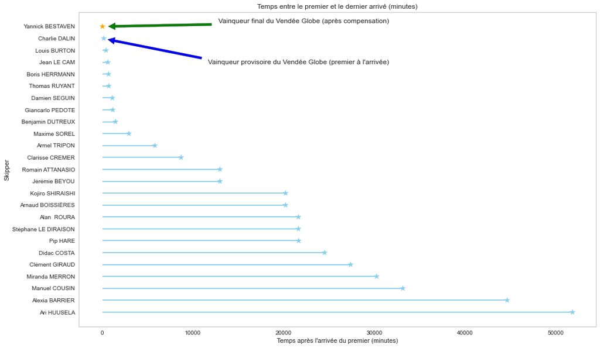

```python
def lollipopplot(df):
    plt.rcParams["figure.figsize"] = (16, 10)
    ordered_df = merged_df.sort_values(by='Time_first', ascending=False)
    my_range = range(1, len(merged_df.index) - 7)
    show_first = np.where(ordered_df['skipper'].iloc[0:25] == 'Yannick BESTAVEN', 'orange', 'skyblue')
    plt.hlines(y=my_range, xmin=0, xmax=ordered_df['Time_first'].iloc[0:25], color=show_first, alpha=1)
    plt.scatter(ordered_df['Time_first'].iloc[0:25], my_range, marker='*', s=100, color=show_first, alpha=1)
    plt.yticks(my_range, ordered_df['skipper'].iloc[0:25])
    plt.grid(False)
    plt.title("Temps entre le premier et le dernier arrivé (minutes)")
    plt.xlabel('Temps après l\'arrivée du premier (minutes)')
    plt.ylabel('Skipper')
    plt.annotate('Vainqueur provisoire du Vendée Globe (premier à l\'arrivée)',
            xy=(0, len(df.index) - 9), xycoords='data',
            xytext=(0.6, 0.85), textcoords='axes fraction',
            arrowprops=dict(facecolor='blue', shrink=0.05),
            horizontalalignment='right', verticalalignment='top')
    plt.annotate('Vainqueur final du Vendée Globe (après compensation)',
        xy=(0, len(df.index) - 8), xycoords='data',
        xytext=(0.6, 0.98), textcoords='axes fraction',
        arrowprops=dict(facecolor='green', shrink=0.05),
        horizontalalignment='right', verticalalignment='top')
    plt.show()

lollipopplot(merged_df)
```

Le graphique ci dessus nous montre l'écart de temps à l'arrivée basé sur le classement final. Il ne montre pas les skippers ayant abandonné pendant la course.  
Nous allons observer la distance réelle parcourue par les différents skippers. Nous verrons que beaucoup de skippers ont fait pas mal de distance en plus par rapport aux premiers. Les parcours n'ont donc pas été forcément optimals.

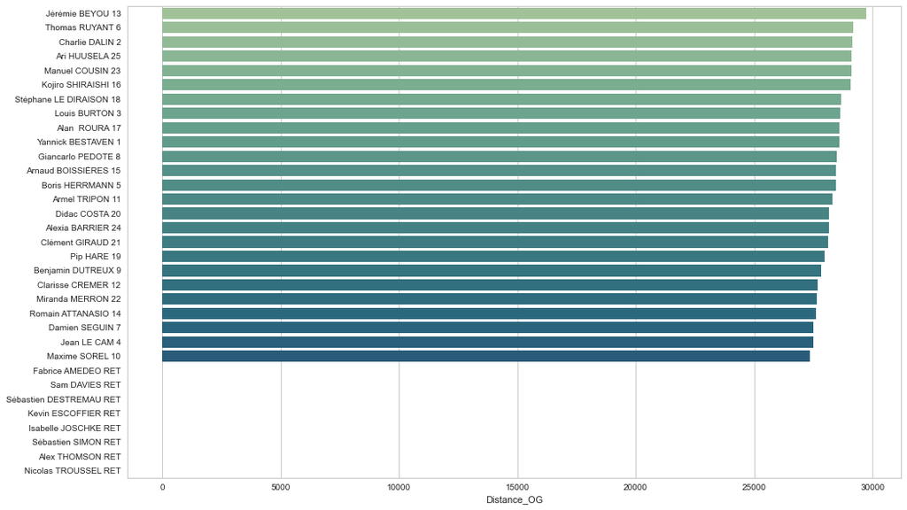

```python
def real_distance(df):
    ordered_df = df.sort_values(by='Distance_OG', ascending=False)
    plt.figure(figsize=(16, 10))
    pal = sns.color_palette("crest", len(df))
    sns.barplot(x='Distance_OG', y=ordered_df['skipper'] + " " + ordered_df['Ranking'], data=ordered_df.fillna(-1),
                palette=pal)
    plt.show()

real_distance(merged_df)
```

#### Analyse des données de course (avant le premier arrivé)

Nous allons maintenant travailler avec les fichiers présents dans le dossier \excels\

```python
merging_files = os.listdir(f'{os.getcwd()}\\excels\\')
df_skipper_number = merged_df[['skipper', 'Number']]
df_skipper_number.head()
```

|  | skipper | Number |
| --- | --- | --- |
| 0 | Fabrice AMEDEO | 0056 |
| 1 | Romain ATTANASIO | 0049 |
| 2 | Alexia BARRIER | 0072 |
| 3 | Yannick BESTAVEN | 0017 |
| 4 | Jérémie BEYOU | 0008 |

**Etape suivante :** Nous nettoyons la dataframe de la même manière que celle du résultat final.

```python
def clean_df(file):
    columns_to_keep = [1, 2, 3, 4, 5, 6, 11, 12, 13, 14, 19, 20]
    column_name = ['Ranking', 'Nat/Voile', 'Skipper/Bateau', 'Heure', 'Latitude', 'Longitude', 'Cap_lastR',
                   'Speed_lastR',
                   'VMG', 'Distance', 'DTF', 'DTL']
    df = pd.read_excel(f'{os.getcwd()}\\excels\\{file}', usecols=columns_to_keep, names=column_name)
    classement_date = df.iloc[1, 0]
    df.drop(range(4), axis=0, inplace=True)
    df.drop(df.tail(4).index, inplace=True)
    df.drop(['Heure', 'Skipper/Bateau'], axis=1, inplace=True)
    df = df.reset_index(drop=True)
    df = df.replace(r'\n', ' ', regex=True)
    df["Nat"] = df['Nat/Voile'].str.extract('([a-zA-Z]{3})')
    df['Number'] = df['Nat/Voile'].str.extract('(\d+)')
    df['Number'] = df['Number'].apply(lambda x: correction_voile(x) if x is not np.nan else x)
    df.drop(['Nat/Voile'], axis=1, inplace=True)
    for cut in ['Speed_lastR', 'VMG', 'Distance', 'DTF', 'DTL']:
        df[cut] = df[cut].apply(lambda x: float(str(x).split(' ')[0]))
    df = pd.merge(df_skipper_number, df, on='Number')
    df.insert(3, 'Date_heure', pd.to_datetime(file[:-5], format='%Y%m%d_%H%M%S', errors='coerce'))
    return classement_date, df
```

**Etape suivante :** Nous fusionons la dataframe de chaque fichiers en une seule unique que nous copierons ensuite dans un fichier csv pour faciliter la lecture et l'utilisation

```python
def letsmerg():
    df = pd.DataFrame()
    for elt in merging_files[1:]:
        b = clean_df(elt)[1]
        df = df.append(b)
    df.to_csv('data_glob.csv')
    return df
```

```python
# Cette cellule a été commentée afin d'éviter de refaire le processus de création de la dataframe et la sauvegarde du csv.
# Cette étape ne se faisant qu'une fois, nous avons déjà le csv présent dans le dossier
# nous n'avons pas besoin de relancer cette fonction.

# merge_all_files_into_one = letsmerg()
```

```python
def read_global_datas():
    return pd.read_csv('data_glob.csv', index_col=0)
```

```python
# Nettoyage de la colonne du numéro de voile et nous passons la colonne Date / Heure en Datetime.
df_glob = read_global_datas()
df_glob['Number'] = df_glob['Number'].apply(lambda x: correction_voile(x) if x is not np.nan else x)
df_glob.Date_heure = pd.to_datetime(df_glob.Date_heure)
```

```python
df_glob.info()
```

```
<class 'pandas.core.frame.DataFrame'>
Int64Index: 15906 entries, 0 to 32
Data columns (total 13 columns):
 #   Column       Non-Null Count  Dtype
---  ------       --------------  -----
 0   skipper      15906 non-null  object
 1   Number       15906 non-null  object
 2   Ranking      15906 non-null  object
 3   Date_heure   15906 non-null  datetime64[ns]
 4   Latitude     13703 non-null  object
 5   Longitude    13703 non-null  object
 6   Cap_lastR    13703 non-null  object
 7   Speed_lastR  13703 non-null  float64
 8   VMG          13703 non-null  float64
 9   Distance     13703 non-null  float64
 10  DTF          13703 non-null  float64
 11  DTL          13703 non-null  float64
 12  Nat          15906 non-null  object
dtypes: datetime64[ns](1), float64(5), object(7)
memory usage: 1.7+ MB
```

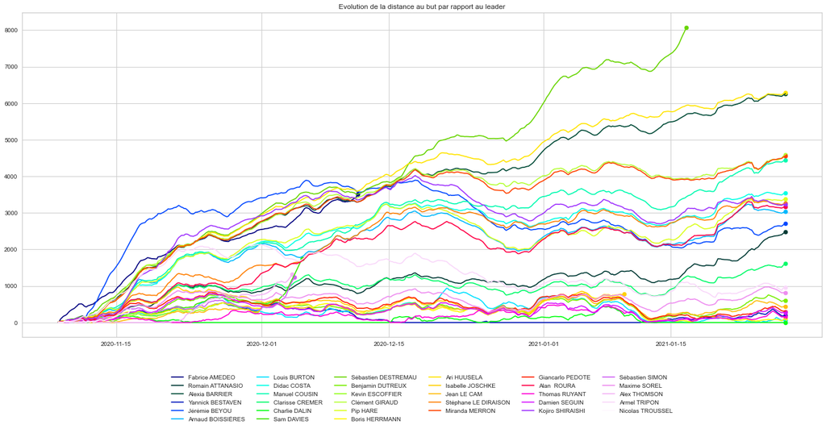

```python
# Nous allons mettre en formation l'évolution au cours du temps de la distance au but par rapport au leader via la colonne DTL
def distance_to_arrival(df_glob):
    colors = plt.cm.gist_ncar(np.linspace(0, 1, len(df_glob['skipper'].unique())))
    i = 0
    plt.figure(figsize=(24, 10))
    for elt in df_glob['skipper'].unique():
        plt.plot(df_glob.loc[df_glob.skipper == elt]['Date_heure'][1:], df_glob.loc[df_glob.skipper == elt]['DTL'][1:],
                 color=colors[i], label=elt)
        plt.scatter((df_glob.loc[(df_glob['Ranking'] != "RET") & (df_glob['skipper'] == elt)])["Date_heure"].iloc[-1],
                    (df_glob.loc[(df_glob['Ranking'] != "RET") & (df_glob['skipper'] == elt)])["DTL"].iloc[-1], color=colors[i])
        i += 1
    plt.title('Evolution de la distance au but par rapport au leader')
    plt.legend(bbox_to_anchor=(0.5, -0.10), loc='upper center', ncol=6, fancybox=True,)
    plt.show()

distance_to_arrival(df_glob)
```

```python
df_glob['DTE'] = 24365.7 - df_glob['DTF'].astype(float)
```

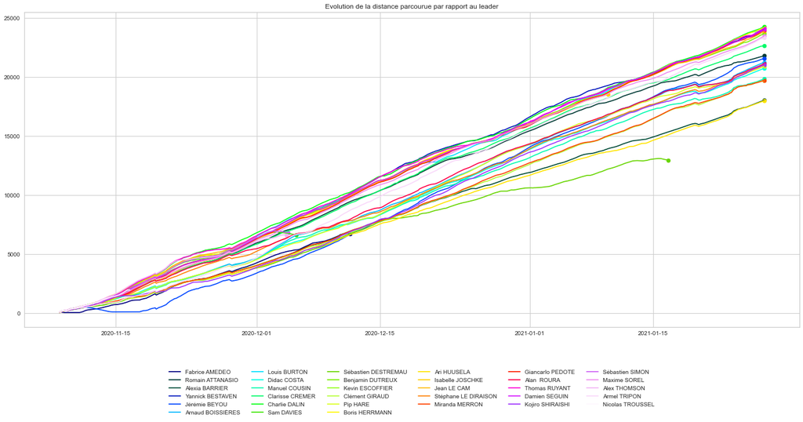

```python
def distance_to_finish(df_glob):
    colors = plt.cm.gist_ncar(np.linspace(0, 1, len(df_glob['skipper'].unique())))
    i = 0
    plt.figure(figsize=(24, 10))
    for elt in df_glob['skipper'].unique():
        plt.plot(df_glob.loc[df_glob.skipper == elt]['Date_heure'][1:], df_glob.loc[df_glob.skipper == elt]['DTE'][1:], color=colors[i],
                 label=elt)
        plt.scatter((df_glob.loc[(df_glob['Ranking'] != "RET") & (df_glob['skipper'] == elt)])["Date_heure"].iloc[-1],
                    (df_glob.loc[(df_glob['Ranking'] != "RET") & (df_glob['skipper'] == elt)])["DTE"].iloc[-1], color=colors[i])
        i += 1
    plt.title('Evolution de la distance parcourue par rapport au leader')
    plt.legend(bbox_to_anchor=(0.5, -0.12), loc='upper center', ncol=6, fancybox=True)
    plt.show()

distance_to_finish(df_glob)
```

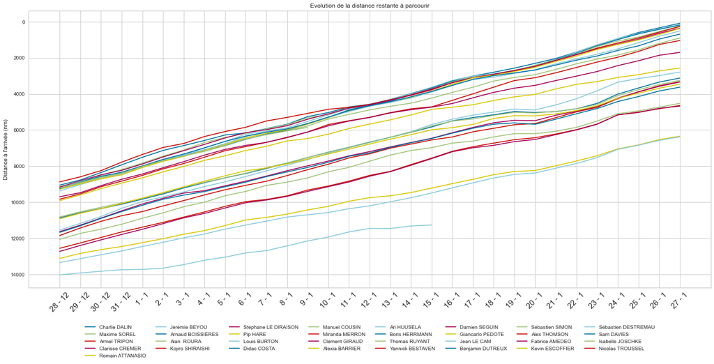

```python
df_glob['mois'] = pd.DatetimeIndex(df_glob['Date_heure']).month
df_glob['jour'] = pd.DatetimeIndex(df_glob['Date_heure']).day
fig, ax = plt.subplots(figsize=(24,10))


ref_jour = df_glob.drop_duplicates(subset="skipper", keep="last").sort_values(by='Ranking')['jour'].values[-1]
ref_mois = df_glob.drop_duplicates(subset="skipper", keep="last").sort_values(by='Ranking')['mois'].values[-1]

for name in df_glob.drop_duplicates(subset="skipper", keep="last").sort_values(by='Ranking').skipper.values:
    sub_db = df_glob.loc[df_glob.skipper == name].drop_duplicates(subset="jour", keep="last")
    jour = sub_db['jour'].drop_duplicates().values[-1]
    mois = sub_db['mois'].drop_duplicates().values[-1]
    if (jour == ref_jour) and (mois == ref_mois):
        plt.plot(sub_db["jour"].apply(str) + " - " + sub_db["mois"].apply(str),sub_db["DTF"],label=name)

plt.xticks(fontsize = 15 , rotation=45)
plt.ylabel("Distance à l'arrivée (nm)")
ax.invert_yaxis()
plt.legend(bbox_to_anchor=(0.5, -0.12), loc='upper center', ncol=8, fancybox=True)
plt.title(f'Evolution de la distance restante à parcourir')
plt.show()
```

Nous allons créer une grande dataframe qui va inclure les données des voiliers pour chaque skipper. Nous allons faire un merge sur le numéro de bateau étant donné que c'est une donnée que nous avons déjà nettoyer entre le site internet et les résultats sur Excel.  
Les noms des skippers n'est pas tout à fait fiable car nous avons pas mal d'erreurs présentes sur le site web ainsi que la gestion des accents et des raccourcis sur les noms sont présents dans les Excels. La meilleure façon est d'identifier le voilier en terme de colonne de merge

```python
big_merged_df = (pd.merge(boats, df_glob, on='Number'))
big_merged_df.drop('skipper_y', axis=1)

print(big_merged_df.info())
big_merged_df.head()
```

```
<class 'pandas.core.frame.DataFrame'>
Int64Index: 15906 entries, 0 to 15905
Data columns (total 31 columns):
 #   Column                  Non-Null Count  Dtype
---  ------                  --------------  -----
 0   name                    15906 non-null  object
 1   skipper_x               15906 non-null  object
 2   Anciens noms du bateau  11568 non-null  object
 3   Architecte              15906 non-null  object
 4   Chantier                15906 non-null  object
 5   Date de lancement       15906 non-null  object
 6   Longueur                15906 non-null  float64
 7   Largeur                 15906 non-null  float64
 8   Tirant_eau              15906 non-null  float64
 9   Dep_poids               15906 non-null  object
```

[output cut: 24 more lines]

|  | name | skipper_x | Anciens noms du bateau | Architecte | Chantier | Date de lancement | ... | DTF | DTL | Nat | DTE | mois | jour |
| --- | --- | --- | --- | --- | --- | --- | --- | --- | --- | --- | --- | --- | --- |
| 0 | NEWREST - ART & FENÊTRES | Fabrice AMEDEO | No Way Back, Vento di Sardegna | VPLP/Verdier | Persico Marine | 01 Août 2015 | ... | 24294.5 | 0.7 | FRA | 71.2 | 11 | 8 |
| 1 | NEWREST - ART & FENÊTRES | Fabrice AMEDEO | No Way Back, Vento di Sardegna | VPLP/Verdier | Persico Marine | 01 Août 2015 | ... | 24271.1 | 6.0 | FRA | 94.6 | 11 | 8 |
| 2 | NEWREST - ART & FENÊTRES | Fabrice AMEDEO | No Way Back, Vento di Sardegna | VPLP/Verdier | Persico Marine | 01 Août 2015 | ... | 24250.9 | 16.0 | FRA | 114.8 | 11 | 8 |
| 3 | NEWREST - ART & FENÊTRES | Fabrice AMEDEO | No Way Back, Vento di Sardegna | VPLP/Verdier | Persico Marine | 01 Août 2015 | ... | 24272.2 | 93.3 | FRA | 93.5 | 11 | 8 |
| 4 | NEWREST - ART & FENÊTRES | Fabrice AMEDEO | No Way Back, Vento di Sardegna | VPLP/Verdier | Persico Marine | 01 Août 2015 | ... | 24298.2 | 165.1 | FRA | 67.5 | 11 | 9 |

5 rows × 31 columns

```python
df_glob = df_glob.set_index('skipper')
```

```python
df_glob.head()
```

| skipper | Number | Ranking | Date_heure | Latitude | Longitude | Cap_lastR | ... | DTF | DTL | Nat | DTE | mois | jour |
| --- | --- | --- | --- | --- | --- | --- | --- | --- | --- | --- | --- | --- | --- |
| Fabrice AMEDEO | 0056 | 6 | 2020-11-08 14:00:00 | 46°25.19'N | 01°49.87'W | 357° | ... | 24294.5 | 0.7 | FRA | 71.2 | 11 | 8 |
| Romain ATTANASIO | 0049 | 13 | 2020-11-08 14:00:00 | 46°25.26'N | 01°49.29'W | 357° | ... | 24294.9 | 1.1 | FRA | 70.8 | 11 | 8 |
| Alexia BARRIER | 0072 | 27 | 2020-11-08 14:00:00 | 46°25.83'N | 01°48.92'W | 357° | ... | 24295.4 | 1.6 | FRA | 70.3 | 11 | 8 |
| Yannick BESTAVEN | 0017 | 17 | 2020-11-08 14:00:00 | 46°25.14'N | 01°48.91'W | 357° | ... | 24295.1 | 1.3 | FRA | 70.6 | 11 | 8 |
| Jérémie BEYOU | 0008 | 3 | 2020-11-08 14:00:00 | 46°24.91'N | 01°49.99'W | 357° | ... | 24294.3 | 0.5 | FRA | 71.4 | 11 | 8 |

5 rows × 15 columns

Nous allons mettre en place un dernier graphique afin d'observer l'évolution du classement pendant la durée de la course.

```python
big_merged_df_filtered =  big_merged_df[~big_merged_df.Ranking.isin(["RET","NL"])]
big_merged_df_filtered['Ranking'] = big_merged_df_filtered['Ranking'].astype(int)
```

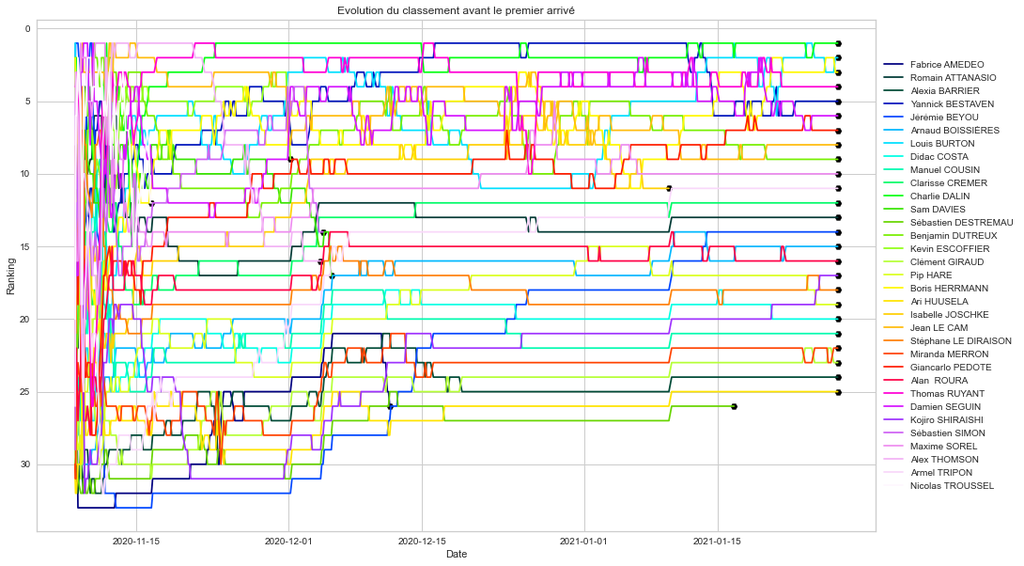

```python
def evolution_classement(big_merged_df_filtered):
    new_df = big_merged_df_filtered.loc[:, ['Date_heure', 'skipper_x', 'Ranking']]
    new_df = new_df.pivot(index='Date_heure', columns='skipper_x')
    new_df = new_df.astype(float)
    colors = plt.cm.gist_ncar(np.linspace(0, 1, len(big_merged_df_filtered['skipper_x'].unique())))
    i = 0
    for elt in big_merged_df['skipper_x'].unique():
        plt.plot(new_df.index, new_df[('Ranking', elt)], label=elt, c=colors[i])
        plt.scatter(new_df.index[new_df[('Ranking', elt)].notnull()][-1], new_df[('Ranking', elt)][new_df[('Ranking', elt)].notnull()][-1], marker='H', s=50, c='black')
        i+=1
    plt.gca().invert_yaxis()
    plt.title('Evolution du classement avant le premier arrivé')
    plt.legend(loc='center left', bbox_to_anchor=(1, 0.5))
    plt.ylabel('Ranking')
    plt.xlabel('Date')
    plt.show()

evolution_classement(big_merged_df_filtered)
```

Bien évidemment, lors des premiers jours il y a beaucoup de changement de position des voiliers étant donné qu'ils partent tous quasiment au même moment, mais au fur et à mesure de la course on voit que l'écart se creuse et que les positions ne changent pas trop vers la fin.

#### Etudes et corrélations

Nous allons tenter de voir les corrélations entre les différents attributs des voiliers. Quelles sont les caractéristiques qui apporteraient une corrélation avec le classement final par exemple.

```python
print(big_merged_df.info())
big_merged_df.head()
```

```
<class 'pandas.core.frame.DataFrame'>
Int64Index: 15906 entries, 0 to 15905
Data columns (total 31 columns):
 #   Column                  Non-Null Count  Dtype
---  ------                  --------------  -----
 0   name                    15906 non-null  object
 1   skipper_x               15906 non-null  object
 2   Anciens noms du bateau  11568 non-null  object
 3   Architecte              15906 non-null  object
 4   Chantier                15906 non-null  object
 5   Date de lancement       15906 non-null  object
 6   Longueur                15906 non-null  float64
 7   Largeur                 15906 non-null  float64
 8   Tirant_eau              15906 non-null  float64
 9   Dep_poids               15906 non-null  object
```

[output cut: 24 more lines]

|  | name | skipper_x | Anciens noms du bateau | Architecte | Chantier | Date de lancement | ... | DTF | DTL | Nat | DTE | mois | jour |
| --- | --- | --- | --- | --- | --- | --- | --- | --- | --- | --- | --- | --- | --- |
| 0 | NEWREST - ART & FENÊTRES | Fabrice AMEDEO | No Way Back, Vento di Sardegna | VPLP/Verdier | Persico Marine | 01 Août 2015 | ... | 24294.5 | 0.7 | FRA | 71.2 | 11 | 8 |
| 1 | NEWREST - ART & FENÊTRES | Fabrice AMEDEO | No Way Back, Vento di Sardegna | VPLP/Verdier | Persico Marine | 01 Août 2015 | ... | 24271.1 | 6.0 | FRA | 94.6 | 11 | 8 |
| 2 | NEWREST - ART & FENÊTRES | Fabrice AMEDEO | No Way Back, Vento di Sardegna | VPLP/Verdier | Persico Marine | 01 Août 2015 | ... | 24250.9 | 16.0 | FRA | 114.8 | 11 | 8 |
| 3 | NEWREST - ART & FENÊTRES | Fabrice AMEDEO | No Way Back, Vento di Sardegna | VPLP/Verdier | Persico Marine | 01 Août 2015 | ... | 24272.2 | 93.3 | FRA | 93.5 | 11 | 8 |
| 4 | NEWREST - ART & FENÊTRES | Fabrice AMEDEO | No Way Back, Vento di Sardegna | VPLP/Verdier | Persico Marine | 01 Août 2015 | ... | 24298.2 | 165.1 | FRA | 67.5 | 11 | 9 |

5 rows × 31 columns

Nous sélectionnons que les colonnes qui nous intéressent à savoir :  
- la vitesse depuis le dernier checkpoint, la VMG (vitesse de rapprochementau but), la largeur du voilier, la hauteur du mat, la surface de la voile au près, la surface de la voila au portant et le classement.

```
               Speed_lastR       VMG   Largeur      Hmat  Surf_vpres  Surf_vportant   Ranking
Speed_lastR       1.000000  0.871703  0.094270  0.033915    0.167289      -0.007376 -0.338326
VMG               0.871703  1.000000  0.066459  0.021290    0.140263      -0.001835 -0.302829
Largeur           0.094270  0.066459  1.000000  0.323025    0.287797       0.108601 -0.242941
Hmat              0.033915  0.021290  0.323025  1.000000    0.446158       0.312065 -0.075654
Surf_vpres        0.167289  0.140263  0.287797  0.446158    1.000000       0.331460 -0.423201
Surf_vportant    -0.007376 -0.001835  0.108601  0.312065    0.331460       1.000000 -0.031028
Ranking          -0.338326 -0.302829 -0.242941 -0.075654   -0.423201      -0.031028  1.000000
```

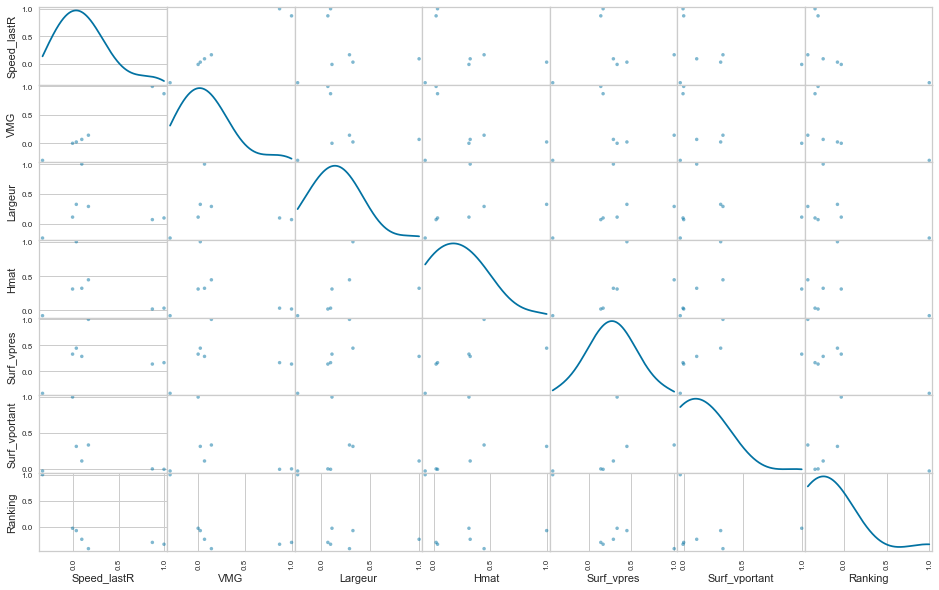

```python
df_correl = big_merged_df[['Speed_lastR', 'VMG', 'Largeur', 'Hmat', 'Surf_vpres', 'Surf_vportant', 'Ranking']]
df_correl = df_correl[(df_correl.Ranking != 'RET') & (df_correl.Ranking != 'NL')]
df_correl['Ranking'] = df_correl['Ranking'].astype(int)
corrLast = df_correl.corr()
print(corrLast)
corrLast.style.background_gradient(cmap='RdYlGn')
pd.plotting.scatter_matrix(corrLast, diagonal='kde')
plt.show()
```

**Analyse:** Nous pouvons voir qu'il y a une grande corrélation entre la vitesse de rapprochement au but et la vitesse du skipper depuis le dernier checkpoint.  
Nous avons aussi des valeurs de corrélation plus forte pour ces couples de données :  
- La surface de voile au près et la hauteur du mat (0.446)  
- Le classement et la surface de voile au près (-0.423)  
- Le classement et la vitesse lors du dernier checkpoint (-0.338).  
Les corrélations pour le rang sont négatifs car plus le rang est petit, meilleur est le classement (et donc plus la vitesse est haute, c'est une relation inverse)

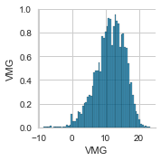

```python
sns.pairplot(big_merged_df[["Ranking","VMG"]])
plt.show()
```

```
-0.3028289189352654
```

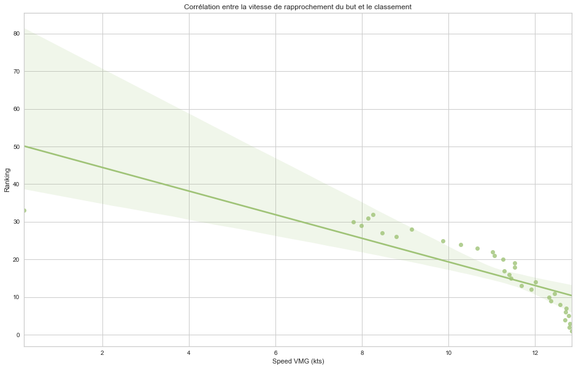

```python
def correlation_ranking_vmg():
    df_corr_rank_vmg =  big_merged_df[~big_merged_df.Ranking.isin(["RET","NL"])]
    df_corr_rank_vmg['Ranking'] = df_corr_rank_vmg['Ranking'].astype(int)
    corr = np.corrcoef(df_corr_rank_vmg['Ranking'],df_corr_rank_vmg['VMG'])[0][1]
    print(corr)
    df_corr_rank_vmg = df_corr_rank_vmg[["Ranking","VMG", "foils"]]
    df_corr_rank_vmg = df_corr_rank_vmg.groupby('Ranking').mean().reset_index()
    sns.regplot(x=df_corr_rank_vmg['VMG'],y=df_corr_rank_vmg['Ranking'], color="g")
    plt.title(f'Corrélation entre la vitesse de rapprochement du but et le classement')
    plt.xlabel(f'Speed VMG (kts)')
    plt.show()

correlation_ranking_vmg()
```

Nous observons bien la corrélation inverse proposée précedemment, plus la VMG augmente et meilleur le classement est. Cette régression linéaire utilise un modèle avec un intervalle de confiance de 95%.

```
-0.3383261500286521
```

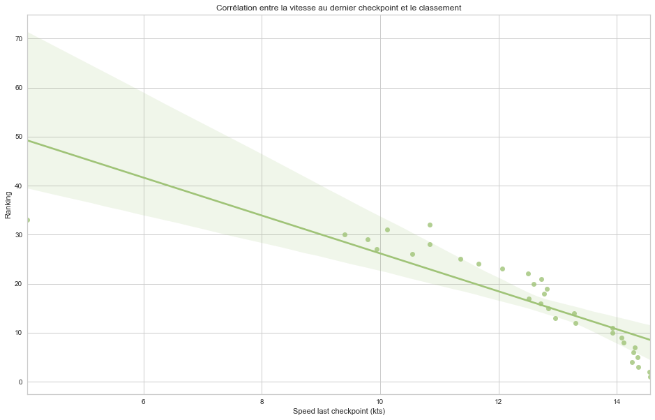

```python
def correlation_ranking_Speed_lastR():
    df_corr_rank_speedR =  big_merged_df[~big_merged_df.Ranking.isin(["RET","NL"])]
    df_corr_rank_speedR['Ranking'] = df_corr_rank_speedR['Ranking'].astype(int)
    corr = np.corrcoef(df_corr_rank_speedR['Ranking'],df_corr_rank_speedR['Speed_lastR'])[0][1]
    print(corr)
    df_corr_rank_speedR = df_corr_rank_speedR[["Ranking","Speed_lastR", "foils"]]
    df_corr_rank_speedR = df_corr_rank_speedR.groupby('Ranking').mean().reset_index()
    sns.regplot(x=df_corr_rank_speedR['Speed_lastR'],y=df_corr_rank_speedR['Ranking'], color="g")
    plt.title(f'Corrélation entre la vitesse au dernier checkpoint et le classement')
    plt.xlabel(f'Speed last checkpoint (kts)')
    plt.show()

correlation_ranking_Speed_lastR()
```

En comparant la vitesse au dernier checkpoint et le ranking, nous avons un coefficient de corrélation plus important avec le classement final.

#### Vérification de l'impact des foils sur le classement final

**Intéressons nous aux foils:** Nous allons voir dans cette partie si les foils ont un impact sur le classement et la vitesse des voiliers

Définition Wikipédia du foil :  
En mécanique des fluides, un foil est une aile positionnée et profilée de façon à engendrer, par son déplacement dans l'eau, une force de portance qui agit sur sa vitesse et sa stabilité.

Définition sur le site du VendéeGlobe du foil :  
Les foils sont les appendices latéraux en forme de "moustache" d'un IMOCA. Le foil immergé transmet une force de portance au bateau lui permettant de s'élever au-dessus de l'eau, de réduire sa traînée et ainsi de gagner en vitesse.

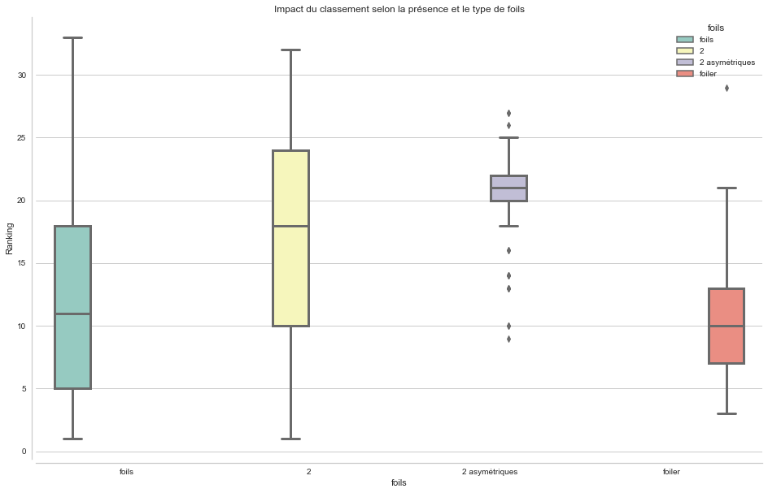

```python
def show_rank_foils():
    df_rank_foils = big_merged_df[~big_merged_df.Ranking.isin(["RET","NL"])]
    df_rank_foils['Ranking'] = df_rank_foils['Ranking'].astype(int)
    sns.boxplot(x="foils", y="Ranking", hue="foils", palette="Set3", data=df_rank_foils[['foils','Ranking']],
                linewidth=3)
    sns.despine(offset=5, trim=False)
    plt.title(f'Impact du classement selon la présence et le type de foils')
    plt.show()

show_rank_foils()
```

Nous voyons que la présence de foils influe sur la position au classement final, nous avons beaucoup plus de voiliers vers le haut du classement avec des foils ou foilers qu'avec des doubles dérives

```python
def count_days(date):
    return (datetime.today() - date).days

big_merged_df["Date de lancement"] = big_merged_df["Date de lancement"].replace({'Janvier': 'January', 'Février': 'February', 'Mars': 'March', 'Avril': 'April', 'Mai': 'May', 'Juin': 'June', 'Juillet': 'July', 'Août': 'August','Septembre': 'September', 'Octobre': 'October', 'Novembre': 'November', 'Décembre': 'December'}, regex=True)
big_merged_df["Date de lancement"] = big_merged_df["Date de lancement"].apply(lambda date: datetime.strptime(date, '%d %B %Y'))
big_merged_df["Date de lancement"] = big_merged_df["Date de lancement"].apply(count_days)
```

Nous allons effectuer la représentation des différents types de dérive selon l'ancienneté du bateau.

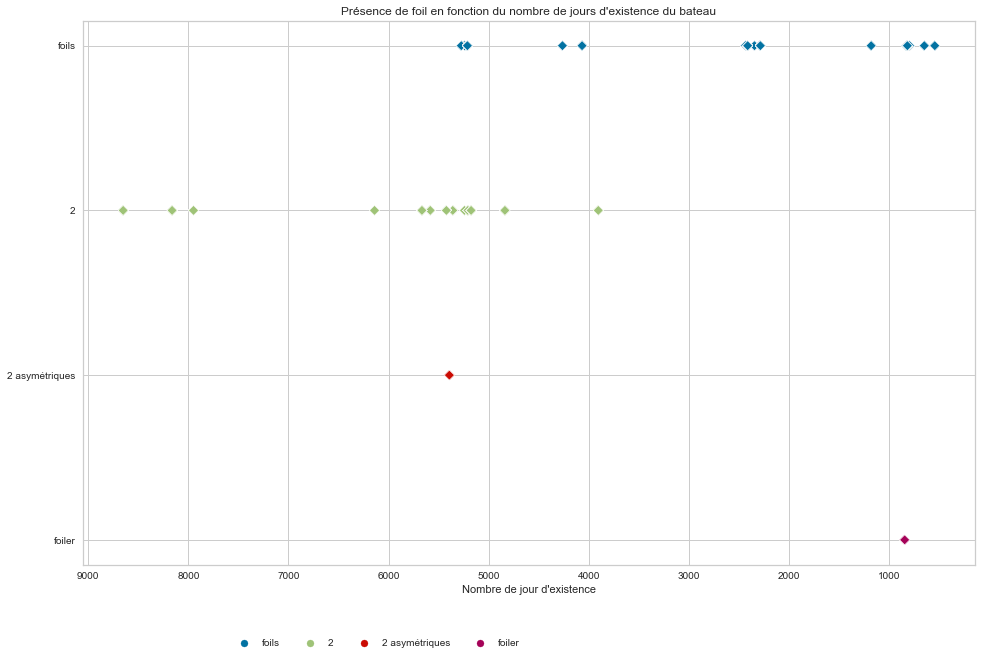

```python
sns.scatterplot(x=big_merged_df["Date de lancement"], y=big_merged_df["foils"], hue=big_merged_df["foils"], marker="D")
plt.xlabel("Nombre de jour d'existence")
plt.ylabel("")
plt.legend(bbox_to_anchor=(0.5, -0.12), ncol=4, fancybox=True)
plt.title("Présence de foil en fonction du nombre de jours d'existence du bateau")
plt.gca().invert_xaxis()
plt.show()
```

Nous observons que les foils sont relativement récents et sont de plus en plus utilisés. Il n'y a plus de doute que maintenant nous ne trouverons que des nouveaux voiliers avec des foils.

```python
big_merged_df = big_merged_df[(big_merged_df.Ranking != 'RET') & (big_merged_df.Ranking != 'NL')]
big_merged_df['Ranking'] = big_merged_df['Ranking'].astype(int)
```

```python
color_names = ['#F0F8FF','#FAEBD7','#00FFFF','#7FFFD4','#F0FFFF','#F5F5DC','#FFE4C4','#000000','#FFEBCD','#0000FF','#8A2BE2',\
'#A52A2A','#DEB887','#5F9EA0','#7FFF00','#D2691E','#FF7F50','#6495ED','#FFF8DC','#DC143C','#00FFFF','#00008B','#008B8B',\
'#B8860B','#A9A9A9','#006400','#BDB76B','#8B008B','#556B2F','#FF8C00','#9932CC','#8B0000','#E9967A','#8FBC8F','#483D8B',\
'#2F4F4F','#00CED1','#9400D3','#FF1493','#00BFFF','#696969','#1E90FF','#B22222','#FFFAF0','#228B22','#FF00FF','#DCDCDC',\
'#F8F8FF','#FFD700','#DAA520','#808080','#008000','#ADFF2F','#F0FFF0','#FF69B4','#CD5C5C','#4B0082','#FFFFF0','#F0E68C',\
'#E6E6FA','#FFF0F5','#7CFC00','#FFFACD','#ADD8E6','#F08080','#E0FFFF','#FAFAD2','#90EE90','#D3D3D3','#FFB6C1','#FFA07A',\
'#20B2AA','#87CEFA','#778899','#B0C4DE','#FFFFE0','#00FF00','#32CD32','#FAF0E6','#FF00FF','#800000','#66CDAA','#0000CD',\
'#BA55D3','#9370DB','#3CB371','#7B68EE','#00FA9A','#48D1CC','#C71585','#191970','#F5FFFA','#FFE4E1','#FFE4B5','#FFDEAD',\
'#000080','#FDF5E6','#808000','#6B8E23','#FFA500','#FF4500','#DA70D6','#EEE8AA','#98FB98','#AFEEEE','#DB7093','#FFEFD5',\
'#FFDAB9','#CD853F','#FFC0CB','#DDA0DD','#B0E0E6','#800080','#FF0000','#BC8F8F','#4169E1','#8B4513','#FA8072','#FAA460',\
'#2E8B57','#FFF5EE','#A0522D','#C0C0C0','#87CEEB','#6A5ACD','#708090','#FFFAFA','#00FF7F','#4682B4','#D2B48C','#008080',\
'#D8BFD8','#FF6347','#40E0D0','#EE82EE','#F5DEB3','#FFFFFF','#F5F5F5','#FFFF00','#9ACD32']
color_name = random.sample(color_names,len(color_names))
```

```python
big_merged_df.info()

big_merged_df['Latitude'] = big_merged_df['Latitude'].apply(str)
big_merged_df['Ranking'] = big_merged_df['Ranking'].apply(str)
big_merged_df['Latitude'] = dms2dec(big_merged_df['Latitude'].values.tolist(),big_merged_df['Ranking'].values.tolist())
big_merged_df['Longitude'] = dms2dec(big_merged_df['Longitude'].values.tolist(),big_merged_df['Ranking'].values.tolist())
big_merged_df['mois'] = pd.DatetimeIndex(big_merged_df['Date_heure']).month
big_merged_df['jour'] = pd.DatetimeIndex(big_merged_df['Date_heure']).day
big_merged_df['heure'] = pd.DatetimeIndex(big_merged_df['Date_heure']).hour
ref_jour = big_merged_df.drop_duplicates(subset="skipper_x", keep="last").sort_values(by='Ranking')['jour'].values[-1]
ref_mois = big_merged_df.drop_duplicates(subset="skipper_x", keep="last").sort_values(by='Ranking')['mois'].values[-1]
```

```
<class 'pandas.core.frame.DataFrame'>
Int64Index: 13703 entries, 0 to 15473
Data columns (total 31 columns):
 #   Column                  Non-Null Count  Dtype
---  ------                  --------------  -----
 0   name                    13703 non-null  object
 1   skipper_x               13703 non-null  object
 2   Anciens noms du bateau  10793 non-null  object
 3   Architecte              13703 non-null  object
 4   Chantier                13703 non-null  object
 5   Date de lancement       13703 non-null  int64
 6   Longueur                13703 non-null  float64
 7   Largeur                 13703 non-null  float64
 8   Tirant_eau              13703 non-null  float64
 9   Dep_poids               13703 non-null  object
```

[output cut: 23 more lines]

Nous allons tracer sur une carte le chemin des différents voiliers ainsi que leur position lors de l'arrivée du premier voilier.  
Nous allons également identifier les voiliers avec deux icones distinctes, une rouge pour les voiliers ayant abandonné et en vert les voiliers étant toujours en course

```python
def draw_beautiful_map(save=False):
    list_marker = []
    list_path = []
    # defaut_size = Layout(width='100%', height='100%')
    m = Map(basemap=basemap_to_tiles(basemaps.OpenStreetMap.Mapnik), zoom=2)

    icon1 = AwesomeIcon(
        name='fa-cog',
        marker_color='red',
        icon_color='black',
        spin=True
    )
    icon2 = AwesomeIcon(
        name='fa-ship',
        marker_color='green',
        icon_color='darkgreen',
        spin=True
    )


    for skipper, color in zip(big_merged_df['skipper_x'].unique(), color_name):
        jour = big_merged_df.loc[big_merged_df.skipper_x == skipper, ['jour']].values
        mois = big_merged_df.loc[big_merged_df.skipper_x == skipper, ['mois']].values
        heure = big_merged_df.loc[big_merged_df.skipper_x == skipper, ['heure']].values
        foil = big_merged_df.loc[big_merged_df.skipper_x == skipper, ['foils']].values[0]
        latitude = big_merged_df.loc[big_merged_df.skipper_x == skipper, ['Latitude']].values[-1][0]
        longitude = big_merged_df.loc[big_merged_df.skipper_x == skipper, ['Longitude']].values[-1][0]
        lastdate = big_merged_df.loc[big_merged_df.skipper_x == skipper, ['Date_heure']].values[-1][0]
        if str(lastdate) == '2021-01-27T14:00:00.000000000':
            icon = icon2
        else:
            icon = icon1
        rang = big_merged_df.loc[big_merged_df.skipper_x == skipper, ['Ranking']].values[-1][0]
        location = big_merged_df.loc[big_merged_df.skipper_x == skipper, ['Latitude', 'Longitude']].values.tolist()
        ant_path = AntPath(name=f"{rang} : {skipper}", locations=location, dash_array=[1, 10], delay=5000,
                                    color=color, pulse_color=color, weight=3)

        message = HTML(value=f"{skipper}: position : {rang} - type de foil : {foil}")
        marker = Marker(name=f"{rang} : {skipper}", icon=icon, location=(latitude, longitude), draggable=False)
        marker.popup = message
        list_marker.append(marker)
        list_path.append(ant_path)
        m.add_layer(marker)
        m.add_layer(ant_path)

    # widget control not working
    # zoom_slider = IntSlider(description='Zoom level:', min=0, max=15, value=7)
    # jslink((zoom_slider, 'value'), (m, 'zoom'))
    # widget_control1 = WidgetControl(widget=zoom_slider, position='bottomleft')
    # m.add_control(widget_control1)

    control = LayersControl(position='topright')
    m.add_control(control)
    m.add_control(FullScreenControl())

    display(m)
    if save:
        m.layout.width = '100%'
        m.layout.height = '800px'
        m.save("Map_Monde_VendeeGlobe.html", title="Map_Monde_VendeeGlobe")

draw_beautiful_map(save=True)
```

Dans cette partie nous allons tenter de représenter les clusters afin d'effectuer des partition et grouper les points afin d'avoir des répartitions homogènes et compacts

```python
def prepare_df_kmeans():
    df_kmean = boats[
        ["Longueur", "Largeur", "Tirant_eau", "Dep_poids", "foils", "Hmat", "Type_Vquille", "Surf_vpres", "Surf_vportant"]]
    df_kmean = df_kmean[~df_kmean.Dep_poids.isin(["nc", "NC"])]
    df_kmean = df_kmean[~df_kmean.Type_Vquille.isin([np.nan])]
    df_kmean['foils'] = df_kmean['foils'].map({'foils': 1, '2 asymétriques': 0, '2': 0, 'foiler': 1}).astype(float)
    df_kmean['Type_Vquille'] = df_kmean['Type_Vquille'].map({'monotype': 0, 'acier forgé': 1, 'acier': 2, 'basculante avec vérin': 3, 'basculante sur vérin hydraulique': 4, 'carbone': 5, 'acier mécano soudé': 6, 'Inox usiné': 7}).astype(float)
    df_kmean['Dep_poids'] = df_kmean['Dep_poids'].astype(float)
    return df_kmean

df_kmean = prepare_df_kmeans()
```

Afin de trouver le nombre de cluster optimisé nous utilisons la méthode kElbowVisualize qui permet de représenter le graph des Kmeans pour un nombre k variant de (a,b) et de pouvoir observer le point d'inflexion ("le coude") ce qui nous permettra de choisir le k optimal

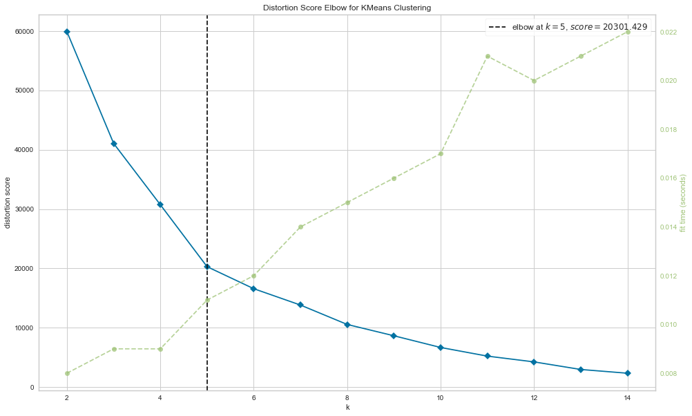

```python
def ranged_kmeans(df_kmean):
    kmeans = KMeans()
    plot_elbow = KElbowVisualizer(kmeans, k=(2, 15))
    plot_elbow.fit(df_kmean)
    plot_elbow.show()

ranged_kmeans(df_kmean)
```

**Analyse:** Nous voyons donc que pour k = 5, nous avons le fit et le score optimal. Nous allons donc utiliser cette valeur pour nos features de données

Préparation du Kmeans pour un nombre de cluster = 5 avec différentes représentations en x et y

```python
plt.rcParams['figure.figsize'] = [10, 10]
plt.rcParams['figure.dpi'] = 100
kmeans = KMeans(n_clusters=5)
k_fit = kmeans.fit(df_kmean)
predictions = k_fit.labels_
df_kmean = df_kmean.assign(Cluster=predictions)
plot_tuple = [('Dep_poids','foils'), ('Hmat','Type_Vquille'), ('Surf_vpres','Surf_vportant'),('Largeur','Surf_vportant'),('Dep_poids','Surf_vpres'),('Hmat','Longueur')]

# Affichage de la dataframe avec les clusters
print(df_kmean)
```

```
         Longueur  Largeur  Tirant_eau  Dep_poids  foils  Hmat  Type_Vquille  Surf_vpres  Surf_vportant  Cluster
FRA 56      18.28     5.85         4.5        7.0    1.0  29.0           0.0         320            570        4
FRA 49      18.28     5.80         4.5        9.0    0.0  28.0           1.0         280            560        0
FRA72       18.28     5.54         4.5        9.0    0.0  29.0           2.0         260            580        0
17          18.28     5.80         4.5        8.0    1.0  29.0           6.0         310            550        0
08          18.28     5.85         4.5        8.0    1.0  29.0           2.0         320            600        4
FRA 14      18.28     5.65         4.5        7.9    1.0  29.0           3.0         300            610        1
18          18.28     5.80         4.5        7.6    1.0  28.0           2.0         300            600        1
ESP 33      18.28     5.30         4.5        8.9    0.0  26.0           2.0         240            470        3
FRA 71      18.28     5.80         4.5        9.0    0.0  28.5           4.0         270            560        0
FRA30       18.28     5.70         4.5        7.7    0.0  29.0           1.0         340            570        4
FRA 79      18.28     5.85         4.5        8.0    1.0  29.0           2.0         350            560        4
FRA109      18.28     5.70         4.5        7.8    1.0  27.0           1.0         300            600        1
69          18.28     5.60         4.5        8.5    0.0  29.0           2.0         250            650        1
FRA09       18.28     5.85         4.5        8.0    0.0  29.0           1.0         300            700        2
FRA83       18.28     5.75         4.5        8.5    0.0  29.0           1.0         300            620        1
GBR77       18.28     5.70         4.5        9.0    0.0  29.0           5.0         300            580        0
16          18.28     5.70         4.5        7.6    1.0  29.0           2.0         290            490        3
FIN222      18.28     5.80         4.5        8.5    0.0  28.0           2.0         270            580        0
FRA 27      18.28     5.60         4.5        7.7    1.0  27.0           2.0         300            650        1
001         18.28     5.90         4.5        8.0    0.0  28.0           1.0         300            620        1
FRA 92      18.28     5.84         4.5        8.5    1.0  28.0           0.0         300            550        0
FRA50       18.28     5.50         4.5        8.5    0.0  28.0           5.0         330            600        4
ITA 34      18.28     5.80         4.5        8.0    1.0  29.0           1.0         300            600        1
FRA 59      18.28     5.85         4.5        8.0    1.0  29.0           1.0         350            560        4
FRA1000     18.28     5.85         4.5        8.5    0.0  29.0           1.0         350            610        4
JPN 11      18.28     5.85         4.5        8.0    1.0  29.0           1.0         320            580        4
4           18.28     5.70         4.5        8.0    1.0  29.0           7.0         260            600        1
FRA53       18.28     5.50         4.5        7.7    0.0  29.0           2.0         365            700        2
GBR 99      18.28     5.40         4.5        7.7    1.0  29.0           1.0         330            630        1
2           18.28     5.50         4.5        7.8    1.0  28.0           1.0         270            535        0
```

```python
df_kmean.info()
```

```
<class 'pandas.core.frame.DataFrame'>
Index: 30 entries, FRA 56 to 2
Data columns (total 10 columns):
 #   Column         Non-Null Count  Dtype
---  ------         --------------  -----
 0   Longueur       30 non-null     float64
 1   Largeur        30 non-null     float64
 2   Tirant_eau     30 non-null     float64
 3   Dep_poids      30 non-null     float64
 4   foils          30 non-null     float64
 5   Hmat           30 non-null     float64
 6   Type_Vquille   30 non-null     float64
 7   Surf_vpres     30 non-null     int64
 8   Surf_vportant  30 non-null     int64
 9   Cluster        30 non-null     int32
dtypes: float64(7), int32(1), int64(2)
memory usage: 2.5+ KB
```

```python
# Affichage des centroids
centroids = k_fit.cluster_centers_
centroids
```

```
array([[1.82800e+01, 5.72250e+00, 4.50000e+00, 8.60000e+00, 3.75000e-01, 2.84375e+01, 2.62500e+00, 2.82500e+02, 5.61875e+02],
       [1.82800e+01, 5.69000e+00, 4.50000e+00, 7.97000e+00, 7.00000e-01, 2.84000e+01, 2.10000e+00, 2.94000e+02, 6.18000e+02],
       [1.82800e+01, 5.67500e+00, 4.50000e+00, 7.85000e+00, 0.00000e+00, 2.90000e+01, 1.50000e+00, 3.32500e+02, 7.00000e+02],
       [1.82800e+01, 5.50000e+00, 4.50000e+00, 8.25000e+00, 5.00000e-01, 2.75000e+01, 2.00000e+00, 2.65000e+02, 4.80000e+02],
       [1.82800e+01, 5.78750e+00, 4.50000e+00, 7.96250e+00, 6.25000e-01, 2.88750e+01, 1.62500e+00, 3.35000e+02, 5.81250e+02]])
```

```python
cluster_colors = np.array(['green', 'blue', 'orange', 'grey', 'purple'])
colors = cluster_colors[k_fit.labels_]
x = df_kmean['Surf_vportant']
y = df_kmean['Dep_poids']
```

[figure not shown]

```python
def kmeans_scatter_surfvport_poids(df_kmean):
    scatter = plt.scatter(x, y, c=colors, marker='o')
    plt.annotate('Vainqueur du Vendée Globe',
                xy=(df_kmean.loc['FRA 79']['Surf_vportant'], df_kmean.loc['FRA 79']['Dep_poids']), xycoords='data',
                xytext=(0.6, 0.85), textcoords='axes fraction',
                arrowprops=dict(facecolor='red', shrink=0.05),
                horizontalalignment='right', verticalalignment='top')
    plt.title('Clustering Kmeans avec les deux variables Surface de voile au portant et le déplacement (poids)')
    plt.xlabel('Surface de voile au portant (m²)')
    plt.ylabel('Déplacement (poids en tonnes)')
    plt.show()

kmeans_scatter_surfvport_poids(df_kmean)
```

Nous allons tracer différentes features entre elles afin de voir la disparité ou non des clusters

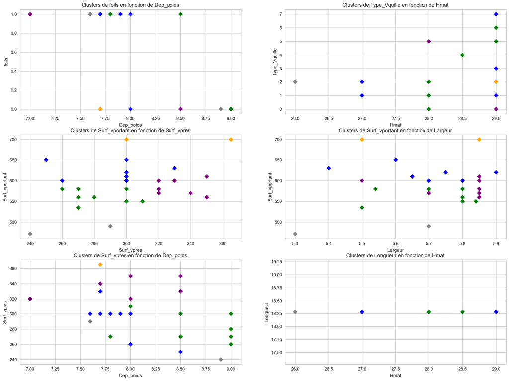

```python
f, axes = plt.subplots(nrows=3, ncols=2, squeeze=False, dpi=200, figsize=[20, 15])
# plt.rcParams['figure.figsize'] = [20, 15]
# plt.rcParams['figure.dpi'] = 100

cluster_colors = np.array(['green', 'blue', 'orange', 'grey', 'purple'])
colors = cluster_colors[k_fit.labels_]
# traçage des différentes combinaisons possible combinations
i, j, k = 0, 0, 0
for key, value in enumerate(plot_tuple):
    var_x = value[0]  # feature in x
    var_y = value[1]  # feature in y

    axes[j][i].scatter(df_kmean[var_x], df_kmean[var_y], c=colors, marker='D', s=50)
    axes[j][i].set_xlabel(str(value[0]), labelpad=5)
    axes[j][i].set_ylabel(str(value[1]), labelpad=5)
    axes[j][i].set_title(f'Clusters de {str(value[1])} en fonction de {str(value[0])}')

    # Formatting between row and cols
    k += 1
    if i < 1:
        i += 1
    else:
        j += 1
        i = 0

plt.show()
```

Les possibilités d'étude sont nombreuses sur ce dataset, il est possible également de faire des méthodes de machine learning afin de voir comment se positionnerait un nouveau voilier avec certaines caractéristiques précises selon les performances historiques. Il est également possible de faire plus de régression logistique sur les différentes composantes technique des voiliers, faire de la prédition de rang en fonction des données existantes. L'idéal serait de prendre aussi les historiques des années précédentes